# ggvita: Visualization for Tree Alignment

Jianrong Philip Yang, Meng Yuan, Xiaolong Cao

2017-10-10

Package ggVITA is developed for tree alignment results visualization. It connects genotype with phenotype during single cell to multiple cells process which is a tree-like development. The algorithms to calculate similarities between trees is designed by Jianrong Philip Yang and his assistants, in Sun Yat-sen University,Guang Zhou. This algoristhm can dectect similar phenotype at the sub tree scale. When we connect both genotype and phenotype of livings, we can observe some interesting phenomenons and find out the biology mechanisms behind them.

**The results should be obtained through HSA software FIRSTLY.**

## Local alignment

- Read the alm file.

```r
the_alm_file <- "~/2017-2018/tree/ggtree_align/data/fun.alm"
readal.alm (the_alm_file)
```

```
The variable alm_label is created.
```

This will create `alm_label` in your environment automately.

- Read the alml file into a list.

This list will contain the results of alml.

- ggvita. This will only show the tree alignment result with phenotypes of terminal tips on treeS and treeT.

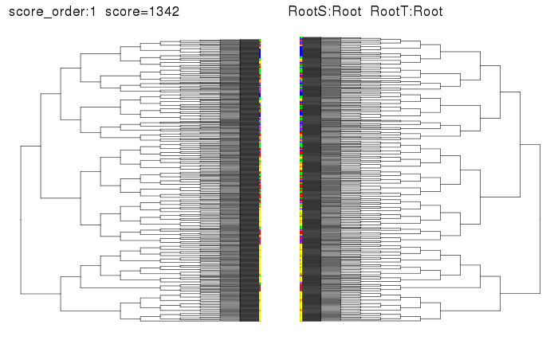

```r
p <- ggvita(the_alml$`1`, print=F)
p
```

- score_order : the order of results, arranged according scores of each results. Scores can be equal across results.
- score: the HSA score calculated by our tree alignment algorithm.
- RootS: the root of the tree on the left.
- RootT: the root of the tree on the right.
- geom_EPIC. This will show the tree alignment result with both genotype and phenotype of treeS and treeT.

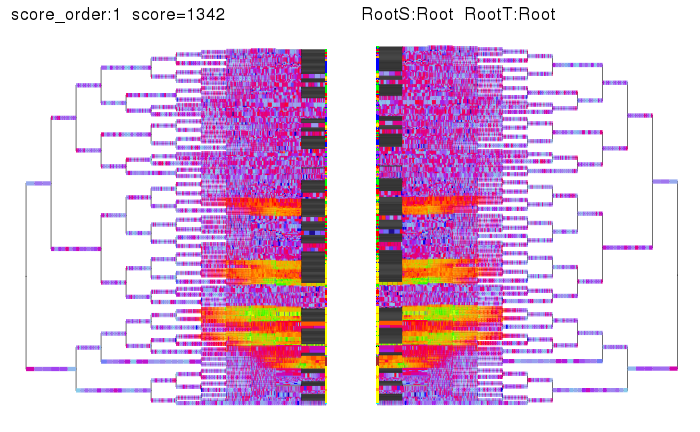

This is an example of PHA-4 gene expression.

Note that ggvita has well compatibility with ggtree and ggplot2 system. Howeve, when you need to add theme_* to ggvita object, use “%+ggvita%” instead.

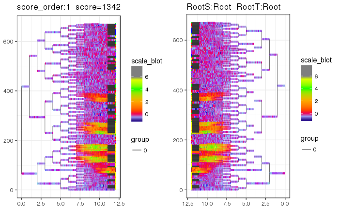

```r
pp %+ggvita% theme_bw()
```

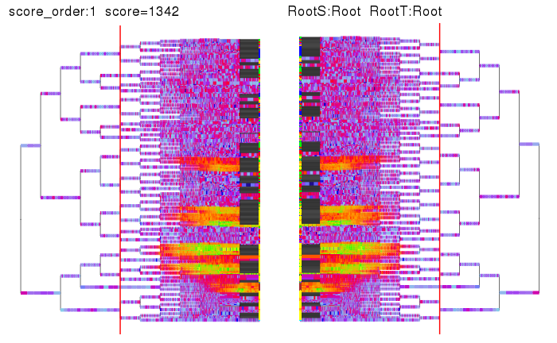

```r
pp+geom_vline(xintercept = 5,color="red")
```

**Have fun!**

Contact with authors via yuanm26@mail2.sysu.edu.cn